# Task5

Mallory Dickerson

9/8/2022

```r
library(tidyverse)
library(downloader)
library(knitr)
```

```r
SoloData <- read_csv("solo-artist-followers.csv")
BillboardData <- read_csv("billboard-hits.csv")
```

```r
str(SoloData)
```

```
## spec_tbl_df [139 x 5] (S3: spec_tbl_df/tbl_df/tbl/data.frame)
##  $ name               : chr [1:139] "Daron Jones" "Slim" "Q Parker" "JC Chasez" ...
##  $ band               : chr [1:139] "112" "112" "112" "*NSYNC" ...
##  $ followers          : chr [1:139] "1.28k" "2.14k" "3.51k" "30.8k" ...
##  $ band_followers     : chr [1:139] "783k" "783k" "783k" "1.44M" ...
##  $ follower_difference: chr [1:139] "-782k" "-781k" "-780k" "-1.41M" ...
##  - attr(*, "spec")=
##   .. cols(
##   ..   name = col_character(),
##   ..   band = col_character(),
##   ..   followers = col_character(),
##   ..   band_followers = col_character(),
##   ..   follower_difference = col_character()
##   .. )
##  - attr(*, "problems")=<externalptr>
```

```r
str(BillboardData)
```

```
## spec_tbl_df [456 x 5] (S3: spec_tbl_df/tbl_df/tbl/data.frame)
##  $ name     : chr [1:456] "*NSYNC" "*NSYNC" "*NSYNC" "*NSYNC" ...
##  $ band     : chr [1:456] NA NA NA NA ...
##  $ title    : chr [1:456] "It's Gonna Be Me" "Music Of My Heart" "Bye Bye Bye" "This I Promise You" ...
##  $ peak_date: Date[1:456], format: "2000-07-28" "1999-10-15" ...
##  $ peak_rank: num [1:456] 1 2 4 5 5 8 11 13 19 59 ...
##  - attr(*, "spec")=
##   .. cols(
##   ..   name = col_character(),
##   ..   band = col_character(),
##   ..   title = col_character(),
##   ..   peak_date = col_date(format = ""),
##   ..   peak_rank = col_double()
##   .. )
##  - attr(*, "problems")=<externalptr>
```

SoloData is a tibble of 139 rows and 5 columns. Each column variable is a character. BillboardData is a tibble of 456 rows and 5 columns. ‘name’, ‘band’, and ‘title’ are characters and peak_date is a Date datatype. ‘peak_rank’ is numeric. I believe it imported correctly.

```r
head(BillboardData)
```

```
## # A tibble: 6 x 5
##   name   band  title                     peak_date  peak_rank
##   <chr>  <chr> <chr>                     <date>         <dbl>
## 1 *NSYNC <NA>  It's Gonna Be Me          2000-07-28         1
## 2 *NSYNC <NA>  Music Of My Heart         1999-10-15         2
## 3 *NSYNC <NA>  Bye Bye Bye               2000-04-14         4
## 4 *NSYNC <NA>  This I Promise You        2000-12-01         5
## 5 *NSYNC <NA>  Girlfriend                2002-04-05         5
## 6 *NSYNC <NA>  A Little More Time On You 1999-02-26         8
```

```r
head(SoloData)
```

```
## # A tibble: 6 x 5
##   name              band   followers band_followers follower_difference
##   <chr>             <chr>  <chr>     <chr>          <chr>
## 1 Daron Jones       112    1.28k     783k           -782k
## 2 Slim              112    2.14k     783k           -781k
## 3 Q Parker          112    3.51k     783k           -780k
## 4 JC Chasez         *NSYNC 30.8k     1.44M          -1.41M
## 5 Joey Fatone       *NSYNC 1.13k     1.44M          -1.44M
## 6 Justin Timberlake *NSYNC 10.3M     1.44M          8.90M
```

```r
times_top_100 <- BillboardData %>%
  filter(is.na(band) == FALSE) %>%
  group_by(name, band) %>%
  summarize(appearance = n()) %>%
  filter(appearance >= 6, na.rm = TRUE)
times_top_100
```

```
## # A tibble: 13 x 3
## # Groups:   name [13]
##    name              band            appearance
##    <chr>             <chr>                <int>
##  1 Beyoncé           Destiny's Child         51
##  2 Bobby Brown       New Edition             11
##  3 Camila Cabello    Fifth Harmony            9
##  4 Harry Styles      One Direction            9
##  5 Johnny Gill       New Edition              7
##  6 Justin Timberlake *NSYNC                  22
##  7 Kelly Rowland     Destiny's Child          6
##  8 Marques Houston   Immature                 6
##  9 Nick Jonas        Jonas Brothers           7
## 10 Omarion           B2K                      6
## 11 Ricky Martin      Menudo                  13
## 12 Romeo Santos      Aventura                 7
## 13 ZAYN              One Direction            8
```

```r
colorline <- BillboardData %>%
  filter(is.na(band) == FALSE) %>%
  filter(name %in% times_top_100$name)

colorline
```

```
## # A tibble: 162 x 5
##    name              band   title                           peak_date  peak_rank
##    <chr>             <chr>  <chr>                           <date>         <dbl>
##  1 Justin Timberlake *NSYNC SexyBack                        2006-09-08         1
##  2 Justin Timberlake *NSYNC My Love                         2006-11-10         1
##  3 Justin Timberlake *NSYNC What Goes Around...Comes Around 2007-03-02         1
##  4 Justin Timberlake *NSYNC Can't Stop The Feeling!         2016-05-27         1
##  5 Justin Timberlake *NSYNC Mirrors                         2013-06-14         2
##  6 Justin Timberlake *NSYNC Cry Me A River                  2003-01-31         3
##  7 Justin Timberlake *NSYNC Suit & Tie                      2013-04-05         3
##  8 Justin Timberlake *NSYNC Rock Your Body                  2003-05-09         5
##  9 Justin Timberlake *NSYNC Summer Love                     2007-06-08         6
## 10 Justin Timberlake *NSYNC Not A Bad Thing                 2014-05-02         8
## # ... with 152 more rows
```

```r
blackline <- BillboardData %>%
  filter(is.na(band) == TRUE) %>%
  filter(name %in% times_top_100$band) %>%
  mutate(band = name)

blackline
```

```
## # A tibble: 115 x 5
##    name   band   title                     peak_date  peak_rank
##    <chr>  <chr>  <chr>                     <date>         <dbl>
##  1 *NSYNC *NSYNC It's Gonna Be Me          2000-07-28         1
##  2 *NSYNC *NSYNC Music Of My Heart         1999-10-15         2
##  3 *NSYNC *NSYNC Bye Bye Bye               2000-04-14         4
##  4 *NSYNC *NSYNC This I Promise You        2000-12-01         5
##  5 *NSYNC *NSYNC Girlfriend                2002-04-05         5
##  6 *NSYNC *NSYNC A Little More Time On You 1999-02-26         8
##  7 *NSYNC *NSYNC Gone                      2001-11-23        11
##  8 *NSYNC *NSYNC I Want You Back           1998-05-01        13
##  9 *NSYNC *NSYNC Pop                       2001-06-15        19
## 10 *NSYNC *NSYNC Tearin' Up My Heart       1998-12-04        59
## # ... with 105 more rows
```

```
## geom_path: Each group consists of only one observation. Do you need to adjust
## the group aesthetic?
```

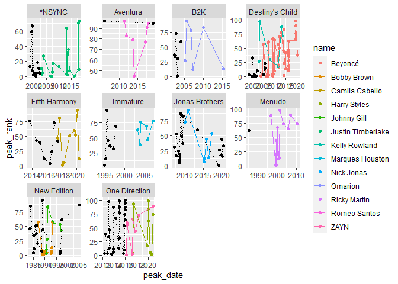

```r
graphpop_bands <- ggplot() +
  geom_point(colorline, mapping = aes(x = peak_date, y = peak_rank, color = name)) +
  geom_line(colorline, mapping = aes(x = peak_date, y = peak_rank, color = name)) +
  geom_point(blackline, mapping = aes(x = peak_date, y = peak_rank), color = "black") +
  geom_line(blackline,  mapping = aes(x = peak_date, y = peak_rank), color = "black", linetype = "dotted") +
  facet_wrap(~ band, scales = "free")


graphpop_bands
```

Beyonce has consistently the most top 100 hits of any solo artists. However, Adventura appears to be a band who was most consistently in the top 100.

Options for Data for Project:

1. https://github.com/fivethirtyeight/data/tree/master/study-drugs some info: Some of the datasets are confidential. The data includes information regarding using a variety of drugs as well as alcohol. It identifies first use as well as ongoing usage.

drugdata <- read_csv (“DS1 National Survey on Drug Use and Health, 2013.csv”)

the variables in this dataset are all numeric

2. https://daac.ornl.gov/cgi-bin/dsviewer.pl?ds_id=1934 some info: This data identifies over 70 variables related to CO2 exchange in the atmosphere. The data is related to the arctic with 244 observation sites related specifically to the tundra.

arctic <- read_csv(“Arctic_Boreal_CO2_Flux.csv”)

data types are either some sort of numeric data, or date, or character.

3. https://academictorrents.com/details/e24e083cc337695bb84a2b68707695579c0ab4d8 some info: Looks at a set of factors that measure and influence student learning. The data looks at 115 first year Engineering majors attending a university in Italy. (University of Genoa)

Finalgrades <- read_csv(final_grades.xlsx) grades <- read_csv(intermediate_grades.xlsx) data types are either dates, characters, or numbers